# Part I - (Ford GoBike System Data)

## Introduction

This dataset contains information on bicycle trips made using the bike-sharing system in the San Francisco Bay Area. This data was collected from the actual system over a specific period of time and includes information such as: duration_sec,start_time,end_time,start_station_id,start_station_name,start_station_latitude.....

## Preliminary Wrangling

```python
# import all packages and set plots to be embedded inline
import numpy as np
import pandas as pd
import matplotlib.pyplot as plt
import seaborn as sns
```

### functions:

#### load data

```python
import pandas as pd

def load_and_preview_dataset(file_path, preview_rows=5):

   #Load a dataset from CSV file and display a preview of the data.

    try:
        # Load the dataset
        df = pd.read_csv(file_path)

        # Display the first few rows
        print(f"Successfully loaded dataset from {file_path}")
        print(f"Shape: {df.shape[0]} rows, {df.shape[1]} columns")
        print("\nPreview:")
        display(df.head(preview_rows))

        return df

    except FileNotFoundError:
        print(f"Error: File not found at {file_path}")
        return None
    except Exception as e:
        print(f"An error occurred: {str(e)}")
        return None
```

## Load the dataset

```python
data = load_and_preview_dataset(file_path='201902-fordgobike-tripdata.csv', preview_rows=3)
```

```
Successfully loaded dataset from 201902-fordgobike-tripdata.csv
Shape: 183412 rows, 16 columns

Preview:
```

|  | duration_sec | start_time | end_time | start_station_id | start_station_name | start_station_latitude | start_station_longitude | end_station_id | end_station_name | end_station_latitude | end_station_longitude | bike_id | user_type | member_birth_year | member_gender | bike_share_for_all_trip |
| --- | --- | --- | --- | --- | --- | --- | --- | --- | --- | --- | --- | --- | --- | --- | --- | --- |
| 0 | 52185 | 2019-02-28 17:32:10.1450 | 2019-03-01 08:01:55.9750 | 21.0 | Montgomery St BART Station (Market St at 2nd St) | 37.789625 | -122.400811 | 13.0 | Commercial St at Montgomery St | 37.794231 | -122.402923 | 4902 | Customer | 1984.0 | Male | No |
| 1 | 42521 | 2019-02-28 18:53:21.7890 | 2019-03-01 06:42:03.0560 | 23.0 | The Embarcadero at Steuart St | 37.791464 | -122.391034 | 81.0 | Berry St at 4th St | 37.775880 | -122.393170 | 2535 | Customer | NaN | NaN | No |
| 2 | 61854 | 2019-02-28 12:13:13.2180 | 2019-03-01 05:24:08.1460 | 86.0 | Market St at Dolores St | 37.769305 | -122.426826 | 3.0 | Powell St BART Station (Market St at 4th St) | 37.786375 | -122.404904 | 5905 | Customer | 1972.0 | Male | No |

### What is the structure of your dataset?

> The dataset consists of 16 columns (Features), where each row represents one trip using a Ford GoBike system bike during February 2019. There are data types: numeric like duration_sec, text like start_station_name, time like end_time, and category like user_type.

### What is/are the main feature(s) of interest in your dataset?

> I'm interested in understanding how long trips typically last, and whether trips differ between user types (subscribers vs. customers). Therefore, the main feature of interest is duration_sec, which represents the duration of each bike trip in seconds.

### What features in the dataset do you think will help support your investigation into your feature(s) of interest?

Several features can help support this analysis:

> start_time and end_time: to explore temporal patterns (e.g., peak hours, weekday vs weekend usage).

> user_type: to compare trip duration between Subscribers and Customers.

## Basic Dataset Exploration

### duplicated rows

```python
data.info()
data.isnull().sum()

# Check for any duplicated rows
print(f"Duplicated rows: {data.duplicated().sum()}")
```

```
<class 'pandas.core.frame.DataFrame'>
RangeIndex: 183412 entries, 0 to 183411
Data columns (total 16 columns):
 #   Column                   Non-Null Count   Dtype
---  ------                   --------------   -----
 0   duration_sec             183412 non-null  int64
 1   start_time               183412 non-null  object
 2   end_time                 183412 non-null  object
 3   start_station_id         183215 non-null  float64
 4   start_station_name       183215 non-null  object
 5   start_station_latitude   183412 non-null  float64
 6   start_station_longitude  183412 non-null  float64
 7   end_station_id           183215 non-null  float64
 8   end_station_name         183215 non-null  object
 9   end_station_latitude     183412 non-null  float64
 10  end_station_longitude    183412 non-null  float64
 11  bike_id                  183412 non-null  int64
 12  user_type                183412 non-null  object
 13  member_birth_year        175147 non-null  float64
 14  member_gender            175147 non-null  object
 15  bike_share_for_all_trip  183412 non-null  object
dtypes: float64(7), int64(2), object(7)
memory usage: 22.4+ MB
Duplicated rows: 0
```

We note that there is no duplication in this dataset.

### Handle Missing Values

It will be checked if there are missing values that affect the accuracy of the analysis.

```python
data.isnull().sum()
```

```
duration_sec                  0
start_time                    0
end_time                      0
start_station_id            197
start_station_name          197
start_station_latitude        0
start_station_longitude       0
end_station_id              197
end_station_name            197
end_station_latitude          0
end_station_longitude         0
bike_id                       0
user_type                     0
member_birth_year          8265
member_gender              8265
bike_share_for_all_trip       0
dtype: int64
```

We find that there are some columns that contain missing values that may affect the accuracy of the analysis, so the matter will be addressed and eliminated.

```python
data = data.dropna(subset=['start_station_id', 'start_station_name', 'end_station_id', 'end_station_name','member_gender', 'member_birth_year'])
data.isnull().sum()
```

```
duration_sec               0
start_time                 0
end_time                   0
start_station_id           0
start_station_name         0
start_station_latitude     0
start_station_longitude    0
end_station_id             0
end_station_name           0
end_station_latitude       0
end_station_longitude      0
bike_id                    0
user_type                  0
member_birth_year          0
member_gender              0
bike_share_for_all_trip    0
dtype: int64
```

### convert time columns to datetime

```python
# convert time columns to datetime
data['start_time'] = pd.to_datetime(data['start_time'])
data['end_time'] = pd.to_datetime(data['end_time'])
data.info()
```

```
<class 'pandas.core.frame.DataFrame'>
Index: 174952 entries, 0 to 183411
Data columns (total 16 columns):
 #   Column                   Non-Null Count   Dtype
---  ------                   --------------   -----
 0   duration_sec             174952 non-null  int64
 1   start_time               174952 non-null  datetime64[ns]
 2   end_time                 174952 non-null  datetime64[ns]
 3   start_station_id         174952 non-null  float64
 4   start_station_name       174952 non-null  object
 5   start_station_latitude   174952 non-null  float64
 6   start_station_longitude  174952 non-null  float64
 7   end_station_id           174952 non-null  float64
 8   end_station_name         174952 non-null  object
 9   end_station_latitude     174952 non-null  float64
 10  end_station_longitude    174952 non-null  float64
 11  bike_id                  174952 non-null  int64
 12  user_type                174952 non-null  object
 13  member_birth_year        174952 non-null  float64
 14  member_gender            174952 non-null  object
 15  bike_share_for_all_trip  174952 non-null  object
dtypes: datetime64[ns](2), float64(7), int64(2), object(5)
memory usage: 22.7+ MB
```

### create new columns

```python
# Create a column for trip duration in minutes
data['duration_min'] = data['duration_sec'] / 60

# Extract the day of the week and the hour from the time
data['start_hour'] = data['start_time'].dt.hour
data['day_of_week'] = data['start_time'].dt.day_name()
```

```python
data.head()
```

|  | duration_sec | start_time | end_time | start_station_id | start_station_name | start_station_latitude | start_station_longitude | end_station_id | end_station_name | end_station_latitude | end_station_longitude | bike_id | user_type | member_birth_year | member_gender | bike_share_for_all_trip | duration_min | start_hour | day_of_week |
| --- | --- | --- | --- | --- | --- | --- | --- | --- | --- | --- | --- | --- | --- | --- | --- | --- | --- | --- | --- |
| 0 | 52185 | 2019-02-28 17:32:10.145 | 2019-03-01 08:01:55.975 | 21.0 | Montgomery St BART Station (Market St at 2nd St) | 37.789625 | -122.400811 | 13.0 | Commercial St at Montgomery St | 37.794231 | -122.402923 | 4902 | Customer | 1984.0 | Male | No | 869.750000 | 17 | Thursday |
| 2 | 61854 | 2019-02-28 12:13:13.218 | 2019-03-01 05:24:08.146 | 86.0 | Market St at Dolores St | 37.769305 | -122.426826 | 3.0 | Powell St BART Station (Market St at 4th St) | 37.786375 | -122.404904 | 5905 | Customer | 1972.0 | Male | No | 1030.900000 | 12 | Thursday |
| 3 | 36490 | 2019-02-28 17:54:26.010 | 2019-03-01 04:02:36.842 | 375.0 | Grove St at Masonic Ave | 37.774836 | -122.446546 | 70.0 | Central Ave at Fell St | 37.773311 | -122.444293 | 6638 | Subscriber | 1989.0 | Other | No | 608.166667 | 17 | Thursday |
| 4 | 1585 | 2019-02-28 23:54:18.549 | 2019-03-01 00:20:44.074 | 7.0 | Frank H Ogawa Plaza | 37.804562 | -122.271738 | 222.0 | 10th Ave at E 15th St | 37.792714 | -122.248780 | 4898 | Subscriber | 1974.0 | Male | Yes | 26.416667 | 23 | Thursday |
| 5 | 1793 | 2019-02-28 23:49:58.632 | 2019-03-01 00:19:51.760 | 93.0 | 4th St at Mission Bay Blvd S | 37.770407 | -122.391198 | 323.0 | Broadway at Kearny | 37.798014 | -122.405950 | 5200 | Subscriber | 1959.0 | Male | No | 29.883333 | 23 | Thursday |

Here we will save cleaned df to a file to deal with later.

```python
# save cleaned df to a file
data.to_csv('data_clean.csv', index=False)
```

### functions:

function to plot histogram

```python
import matplotlib.pyplot as plt
import seaborn as sns

def plot_histogram(data, column, max_value=None, bins=30, color='skyblue', xlabel=None, title=None):

    plt.figure(figsize=(10, 6))

    if max_value is not None:
        filtered_data = data[data[column] <= max_value]
    else:
        filtered_data = data

    sns.histplot(data=filtered_data, x=column, bins=bins, color=color, edgecolor='black')

    if title is None:
        title = f'Histogram of {column}'
    plt.title(title, fontsize=14)

    if xlabel is None:
        xlabel = column
    plt.xlabel(xlabel, fontsize=12)

    plt.ylabel('Count', fontsize=12)
    plt.grid(True)
    plt.tight_layout()
    plt.show()
```

## Univariate Exploration

### What is the distribution of trip durations in minutes?

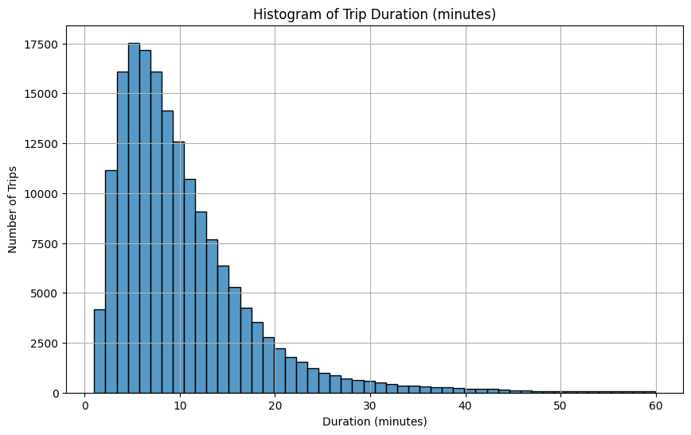

```python
import matplotlib.pyplot as plt
import seaborn as sns

# Histogram to show the distribution of trip durations (in minutes), capped at 60 minutes
plt.figure(figsize=(10, 6))
sns.histplot(data=data[data['duration_min'] <= 60], x='duration_min', bins=50, kde=False)

plt.title('Histogram of Trip Duration (minutes)')
plt.xlabel('Duration (minutes)')
plt.ylabel('Number of Trips')
plt.grid(True)
plt.show()
```

### What is the distribution of trip durations in minutes?

> We note that most trips last less than 20 minutes, and there are also long trips longer than 60 minutes, which have been temporarily ignored to reflect the true distribution of the rest of the data. We find that the distribution is skewed to the right.

### What is the distribution of user types?

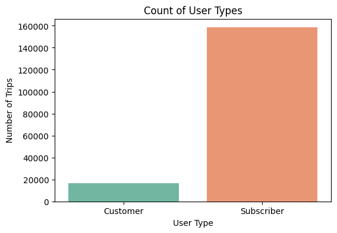

```python
plt.figure(figsize=(6, 4))
sns.countplot(data=data, x='user_type', palette='Set2')

plt.title('Count of User Types')
plt.xlabel('User Type')
plt.ylabel('Number of Trips')
plt.show()
```

> We note that the number of Subscribers was larger than the number of Customers, which indicates that the majority of users have permanent subscriptions.

### What is the distribution of member gender?

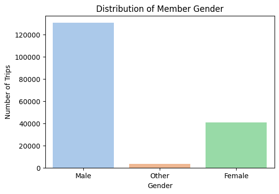

```python
plt.figure(figsize=(6, 4))
sns.countplot(data=data, x='member_gender', palette='pastel')

plt.title('Distribution of Member Gender')
plt.xlabel('Gender')
plt.ylabel('Number of Trips')
plt.show()
```

We notice a difference in the gender of users, with the largest percentage being males, followed by females, and a very small percentage being Other.

### Of the features you investigated, were there any unusual distributions? Did you perform any operations on the data to tidy, adjust, or change the form of the data? If so, why did you do this?

> I deleted rows with missing values, converted duration_sec to minutes, and temporarily ignored values above 60 minutes in the graph because they are considered outliers and distort the overall distribution. Finally, I converted (start_time, end_time) to datetime to facilitate information extraction.

## Bivariate Exploration

Does the trip duration vary depending on the user type?

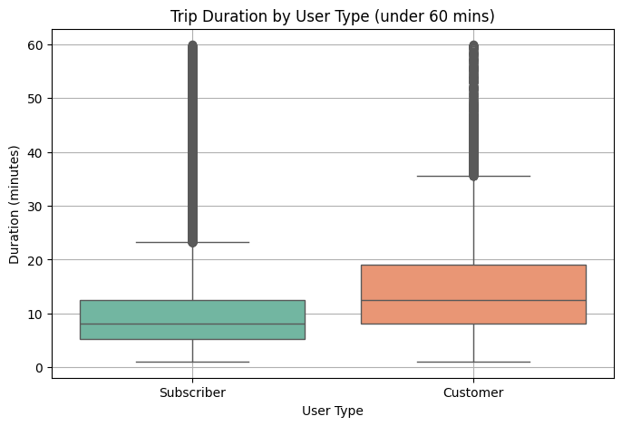

```python
plt.figure(figsize=(8, 5))
sns.boxplot(data=data[data['duration_min'] <= 60], x='user_type', y='duration_min', palette='Set2')

plt.title('Trip Duration by User Type (under 60 mins)')
plt.xlabel('User Type')
plt.ylabel('Duration (minutes)')
plt.grid(True)
plt.show()
```

We notice that customers use the bike for longer periods, while subscribers have shorter trips, as they use it for daily commuting.

### At what times of day do customers and subscribers use the service?

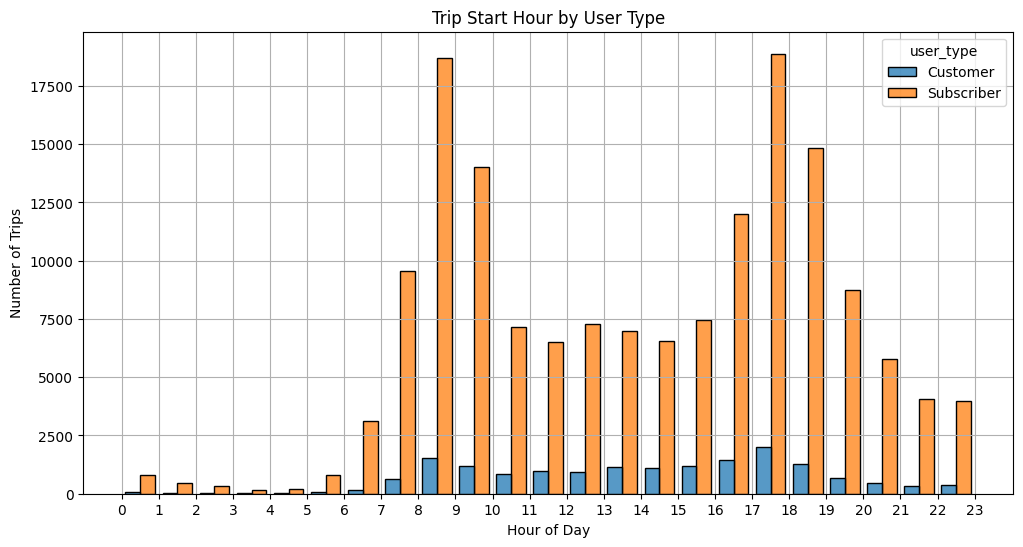

```python
data['start_hour'] = data['start_time'].dt.hour

plt.figure(figsize=(12, 6))
sns.histplot(data=data, x='start_hour', hue='user_type', multiple='dodge', shrink=0.8, binwidth=1)

plt.title('Trip Start Hour by User Type')
plt.xlabel('Hour of Day')
plt.ylabel('Number of Trips')
plt.xticks(range(0, 24))
plt.grid(True)
plt.show()
```

### What is the relationship between Trip Duration and Rider Age?

[figure not shown]

```python
import seaborn as sns
import matplotlib.pyplot as plt


data['rider_age'] = 2019 - data['member_birth_year']
data['duration_min'] = data['duration_sec'] / 60

df_age_filtered = data[(data['rider_age'] >= 23) &
                           (data['rider_age'] <= 80) &
                           (data['duration_min'] <= 100)]

plt.figure(figsize=(20, 6))
sns.stripplot(data=df_age_filtered,
              x='rider_age',
              y='duration_min',
              size=2,
              jitter=0.35,
              color='blue')

plt.title('Scatter Plot with Jitter: Trip Duration vs Rider Age')
plt.xlabel('Rider Age')
plt.ylabel('Trip Duration (Minutes)')
plt.xlim(23, 80)
plt.ylim(0, 100)
plt.grid(True)
plt.show()
```

There is no clear pattern indicating that flight duration increases or decreases significantly with age, which means that age is not the primary factor in determining flight duration.

## Multivariate Exploration

How does trip duration vary by user type and gender?

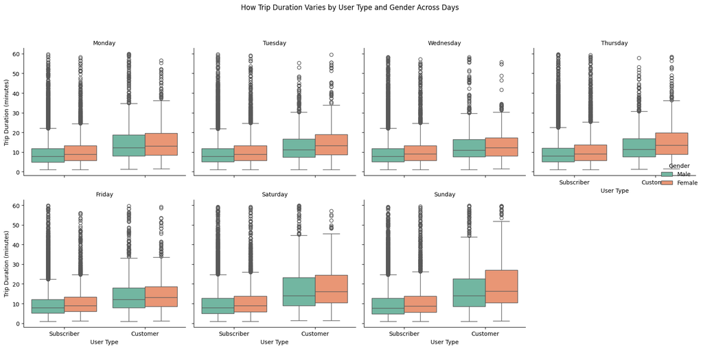

```python
import seaborn as sns
import matplotlib.pyplot as plt
import pandas as pd

# Clean and prepare data
data['member_age'] = 2025 - data['member_birth_year']
ordered_days = ['Monday', 'Tuesday', 'Wednesday', 'Thursday', 'Friday', 'Saturday', 'Sunday']
data['day_of_week'] = pd.Categorical(data['day_of_week'], categories=ordered_days, ordered=True)

# Filter for logical values
subset = data[
    (data['duration_min'] <= 60) &
    (data['member_gender'].isin(['Male', 'Female'])) &
    (data['user_type'].isin(['Customer', 'Subscriber']))
]

# Create FacetGrid
g = sns.FacetGrid(
    subset,
    col='day_of_week',
    col_wrap=4,
    height=4,
    aspect=1,
    sharey=True,
    sharex=True
)

# Map boxplots to each facet
g.map_dataframe(
    sns.boxplot,
    x='user_type',
    y='duration_min',
    hue='member_gender',
    palette='Set2'
)

# Add titles and labels
g.set_titles('{col_name}')
g.set_axis_labels('User Type', 'Trip Duration (minutes)')
g.add_legend(title='Gender')
g.fig.suptitle('How Trip Duration Varies by User Type and Gender Across Days', y=1.05)
plt.tight_layout()
plt.show()
```

We note through the analysis that customers take longer trips than male subscribers. We also find that female customers take the longest trips of all, especially on weekends (Saturday and Sunday). This indicates that they use the service for travel and entertainment. Meanwhile, weekday subscribers, especially males, take shorter trips. This indicates that they use the service frequently, such as commuting to work.

What is the relationship between trip duration, day of the week, and user type?

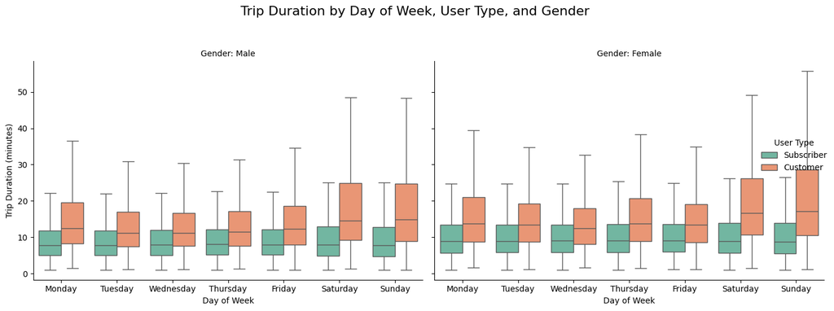

```python
import seaborn as sns
import matplotlib.pyplot as plt
import pandas as pd

# Prepare data
plot_data = data[(data['duration_min'] <= 120) &
                 (data['user_type'].isin(['Customer', 'Subscriber'])) &
                 (data['member_gender'].isin(['Male', 'Female']))].copy()

day_order = ['Monday', 'Tuesday', 'Wednesday', 'Thursday', 'Friday', 'Saturday', 'Sunday']
plot_data['day_of_week'] = pd.Categorical(plot_data['day_of_week'], categories=day_order, ordered=True)

# Create FacetGrid
g = sns.FacetGrid(
    plot_data,
    col='member_gender',  # Faceting by gender
    height=5,
    aspect=1.3,
    sharey=True,
    sharex=True
)

# Map boxplots to each facet
g.map_dataframe(
    sns.boxplot,
    x='day_of_week',
    y='duration_min',
    hue='user_type',
    palette='Set2',
    showfliers=False
)

# Titles and axis labels
g.set_axis_labels("Day of Week", "Trip Duration (minutes)")
g.set_titles("Gender: {col_name}")
g.add_legend(title="User Type")
g.fig.suptitle("Trip Duration by Day of Week, User Type, and Gender", fontsize=16, y=1.05)

plt.tight_layout()
plt.show()
```

### Talk about some of the relationships you observed in this part of the investigation. Were there features that strengthened each other in terms of looking at your feature(s) of interest?

> The Relationship Between User Type and Trip Duration:

In general, customers take longer trips than subscribers.

This pattern was evident in both analyses, whether comparing men and women, or comparing days of the week.

> The Relationship Between Day of the Week and Trip Duration:

Weekends (Saturday and Sunday) see the longest trips, particularly among customers, indicating leisure or tourism use.

On weekdays, trip durations are shorter, especially among subscribers, indicating daily commuting use (e.g., for work or study).

> The Relationship Between Gender and Trip Duration:

Women, both customers and subscribers, spend longer on trips than men on most days.

However, the difference between customers and subscribers remains the most pronounced, regardless of gender.

### Were there any interesting or surprising interactions between features?

> I found an interaction between user type and day of the week, with customers taking longer trips on weekends, while subscribers didn't see a significant difference in trip duration on any given day. There was also an interaction between gender and user type, with female customers taking longer trips than other categories, especially on holidays. Conversely, male subscribers tended to take shorter trips. Also interesting is that the distribution of trip durations among customers was much wider than among subscribers.

## Conclusions

> User type differences: The number of subscribers varies greatly when counting customers, and customers take longer trips than subscribers.

> Gender differences: Males outnumber females on trips, followed by a smaller percentage of others. However, female customers tend to use trips more on weekends.